# Carbon bias of tariffs: are fossil fuels the culprits?

Cecilia Bellora

CEPII

Lionel Fontagné

PSE

Christophe Gouel

INRAE

CEPII

Youssef Salib

PSE, Ecole Nationale des Ponts et Chaussées

CEPII

# Introduction

## Trade and climate transition

- Climate urgency $\Rightarrow$ Reconsider the consistency of policies wrt climate objectives
- In absence of uniform carbon pricing, trade policy structure affects emissions
- Are current trade policies consistent with climate objectives?

## Shapiro (2021, QJE)

### The Environmental Bias of Trade Policy

- Econometrics and simulation results
- Econometrics results for **manufacturing** only:
  - Bias of trade policy toward carbon intensive goods
  - Implicit carbon subsidy of 40$/tCO$_2$
- Political economy explanation:
  - Upstream sectors are more polluting
  - Upstream sectors have less tariffs because of lobbying

## Shapiro (2021, QJE)

- Quantitative model with **all sectors**:
  - Removing sectoral heterogeneity in bilateral relationships
  - 3.6% reduction in world emissions with tariffs and non-tariff barriers
  - 1.75% reduction with tariffs only (more than EU-ETS)
  - No reduction in welfare
  - Grounds for reform?

## Other contributions on the carbon bias of trade policies

- All sectors following Shapiro (2021)
  - Econometrics
    - Chepeliev and Corong (2022), extension to all GHG $\Rightarrow$ smaller bias
    - Moreira and Dolabella (2024), all GHG and sectors in Latin America: highly heterogeneous bias
  - Modeling
    - Klotz and Sharma (2023), similar model but different accounting of emissions and data $\Rightarrow$ 10 times smaller bias
- Agriculture: Laborde et al. (2020) and Guerrero et al. (2022) show that agricultural tariffs decrease emissions

## Our contribution

- What we do
  - Quantitative trade model (Shapiro’s model + extensions)
  - Counterfactual trade policy simulation (tariffs only)
  - Focus on emission implications
- Dissecting Shapiro’s result
  - Extension 2007–19 and **all GHG**
  - More recent data
  - Sectoral analysis
  - Fossil fuel extension:
    - Finite natural resources
    - Domestic taxes
- Results
  - The bias is present for all years
  - It is much smaller when all GHG are included
  - The low tariffs on fossil fuels explain nearly all the bias
  - With the extensions, the bias is abolished or reversed

# Data

## 4 main sources of data

- EXIOBASE 3 world input-output tables 2007–19
  - Also used for GHG emissions other than CO$_2$ from fossils
- MAcMap-HS6 tariffs database
  - Every 3 years: 2007, 2010, 2013, 2016, 2019
  - Interpolated for other years
  - MFN and preferential tariffs in ad valorem equivalent
- IEA world energy balances for energy data (yearly)
- GTAP 11 for oil/gas/coal natural resource rents

## Descriptive statistics

- Statistics for 2019
- Mean tariffs
- Diff. to mean

| Sector | Average tariff (%) | % of imports in sector aggregate supply | CO<sub>2</sub> intensity (kg/€) | Non-CO<sub>2</sub> GHG intensity (kg/€) |
| --- | --- | --- | --- | --- |
| Agriculture | 6.82 | 13.46 | 0.13 | 1.19 |
| Fossil Extraction | 0.31 | 47.09 | 0.69 | 1.28 |
| Brown Industries | 1.93 | 25.11 | 0.31 | 0.12 |
| Manufacturing n.e.s. | 2.98 | 28.56 | 0.07 | 0.00 |
| Services | 0.00 | 3.78 | 0.17 | 0.01 |

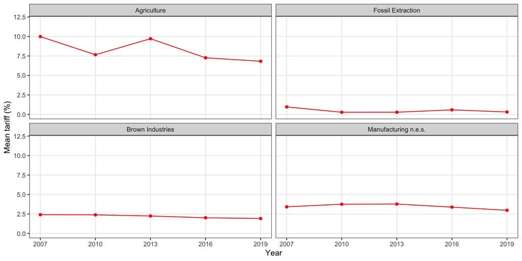

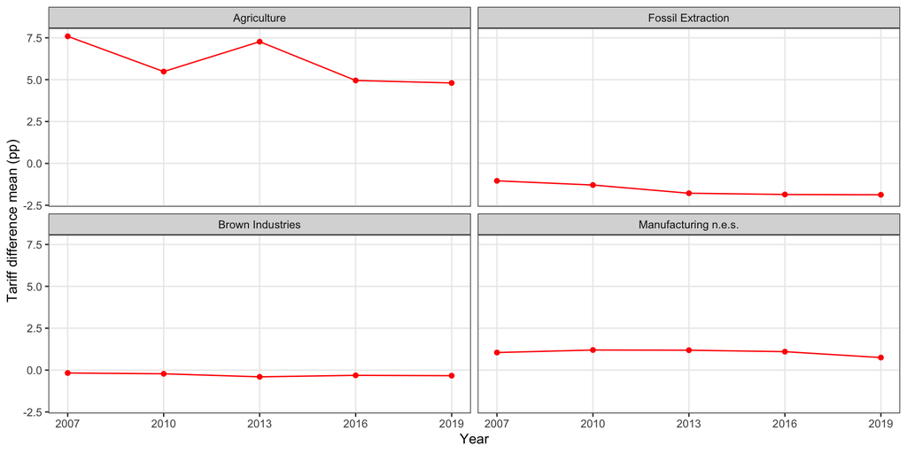

# Model

## Model general description

- NQTM, based on Caliendo and Parro (2015)
  - Parsimonious CGE, calibrated in exact hat algebra
  - Armington type of model
- Production
  - With labor (value added) and intermediate goods
  - Cobb–Douglas, constant returns to scale
- Initial equilibrium calibrated on EXIOBASE
- Trade elasticities from Shapiro (2021)
- 2 aggregations
  - 10 regions, 21 sectors (Shapiro’s aggregation)
  - 23 regions, 47 sectors

## Households

- Cobb–Douglas preferences over composite final goods:
  $$U_{j}=\prod_{k\in\mathcal{K}}\left(D_{j,k}^{\text{FC}}\right)^{\theta_{j,k}^{U}}$$
  - $D_{j,k}^{\text{FC}}$: final demand for composite good $k$ in country $j$
  - $\theta_{j,k}^{U}$: share of expenditure spent on $k$
- CES Composite final goods:
  $$D^{\text{FC}}_{j,k}=\left[\sum_{i\in\mathcal{I}}\beta_{ij,k}^{1/\sigma_{k}}\left(D_{ij,k}^{\text{FC}}\right)^{{(\sigma_{k}-1)}/{\sigma_{k}}}
  \right]^{{\sigma_{k}}/{(\sigma_{k}-1)}}$$
  - $\beta_{ij,k}$: demand shifter
  - $\sigma_{k}>1$: elasticity of substitution between varieties

## Production costs

- Production combines labor and a composite intermediate good according to a Cobb–Douglas
- Unit cost :
  $$c_{i,l}= \left(\frac{w_{i}}{\theta_{i,l}^w} \right)^{\theta_{i,l}^w}\prod_{k\in \mathcal{K}} \left(\frac{p_{i,k}}{\theta_{i,kl}}\right)^{\theta_{i,kl}}$$
  - $w_{i}$: wage
  - $\theta_{i,kl}\in[0,1]$ input-output coefficients
  - $\theta^w_{i,l}=1-\sum_{k\in\mathcal{K}}\theta_{i,kl}$ cost share of labor

## Trade

- Trade costs
  - Iceberg trade costs: $\tau_{ij,k}$
  - Tariffs: $T_{ij,k}=1+t_{ij,k}$

  $$p_{ij,k}=T_{ij,k} \tau_{ij,k} c_{i,k}$$
- Same Armington with elasticity $\sigma_k$ for final and intermediate demands
- Gravity equation

  $$T_{ij,k}X_{ij,k}=\beta_{ij,k}\left(p_{ij,k}/p_{j,k}\right)^{1-\sigma_k}E_{j,k}$$

## Model equations (in EHA, $\hat{x}=x'/x$)

$$\begin{align}
\label{eq:40} \hat{p}_{ij,k}&:\hat{p}_{ij,k}=\hat{T}_{ij,k}\hat{\tau}_{ij,k}\hat{c}_{i,k},\\
\label{eq:53}
\hat{c}_{i,l}&: \hat{c}_{i,l}= \prod_{f\in \mathcal{F}} \left(\hat{w}_{i,f}\right)^{\theta_{i,f,l}^w}\prod_{k\in \mathcal{K}} \left(\hat{p}_{i,k}\right)^{\theta_{i,kl}},\\
\label{eq:63}
\hat{w}_{j,f}&:w_{j,f}L_{j,f}\hat{w}_{j,f}=\sum_{l\in\mathcal{K}}\theta_{j,f,l}^w R_{j,l}\hat{c}_{j,l}\hat{Q}_{j,l},\\
\label{eq:62}
\hat{E}_{j,k}&:E_{j,k}\hat{E}_{j,k}=\theta_{j,k}^{U}GNE_{j}\widehat{GNE}_{j}
+\sum_{l\in\mathcal{K}}\theta_{j,kl}R_{j,l}\hat{c}_{j,l}\hat{Q}_{j,l},\\
\label{eq:48}
\hat{Q}_{i,k}&:\hat{c}_{i,k}\hat{Q}_{i,k}=\sum_{j\in\mathcal{I}}\theta^{R}_{ij,k}\hat{X}_{ij,k},\\
\label{eq:61}
\hat{X}_{ij,k}&:\hat{T}_{ij,k}\hat{X}_{ij,k}=\hat{p}_{ij,k}^{1-\sigma_{k}}\hat{p}_{j,k}^{\sigma_{k}-1}\hat{E}_{j,k},\\
\label{eq:p}
\hat{p}_{j,k}&:\hat{p}_{j,k}=\left(\sum_{i\in\mathcal{I}}\theta_{ij,k}^{X}\hat{p}_{ij,k}^{1-\sigma_{k}}\right)^{{1}/{(1-\sigma_{k})}},\\
\label{eq:75}
\widehat{GNE}_{j}&:GNE_{j}\widehat{GNE}_{j}=GDP_{j}\widehat{GDP}_{j}+\Delta_{j}\hat{\Delta}_{j}\\
\label{eq:6}
\widehat{GDP}_{j}&:GDP_{j}\widehat{GDP}_{j}=\sum_{f\in\mathcal{F}}w_{j,f}L_{j,f}\hat{w}_{j,f}
+\sum_{i\in\mathcal{I}}\sum_{k\in\mathcal{K}}t'_{ij,k}X_{ij,k}\hat{X}_{ij,k}
\end{align}$$

## GHG accounting

- CO$_2$ emissions from fossil fuel combustion
  - Associated to extracted fossil fuels
  - Emissions are proportional to extracted volume of coal, oil, and gas
  - Similar to Shapiro (2021)
  - Recalculated emission factor for each location (IEA data)
- Other GHG emissions proportional to change in:
  - Production in volume for production sectors
  - Consumption in volume for final consumption

## The exogenous shock

- Harmonize tariffs between sectors: $\bar{t}_{ij} = \sum_{k\in\mathcal{G}} t_{ij,k}X_{ij,k}/\sum_{k\in\mathcal{G}} X_{ij,k}$
- One tariff level (the pre-shock average) for all imports from country $i$ to $j$.

Tariff shock by main sector in reference scenario

| Sector | Average tariff shock (pp) |
| --- | --- |
| Agriculture | -4.44 |
| Fossil Extraction | 2.21 |
| Brown Industries | 0.69 |
| Manufacturing n.e.s. | -0.44 |

# Results

## Shapiro replication and extension

Shock emission % change when considering only CO<sub>2</sub> or all GHG

| Scenario | CO<sub>2</sub> | All GHG | CO<sub>2</sub> part | Other GHG part |
| --- | --- | --- | --- | --- |
| 1. Shapiro (2021): Shapiro’s data, shock, and aggregation, year = 2007 | -1.75 | -1.03 | -1.25 | 0.22 |
| 2. Updated economic calibration data (excluding CO<sub>2</sub>) | -1.77 | -1.18 | -1.26 | 0.08 |
| 3. Update calibration data (including CO<sub>2</sub>) | -1.50 | -0.98 | -1.06 | 0.08 |
| 4. No shock on services | -1.72 | -1.16 | -1.22 | 0.05 |
| 5. Our sectoral aggregation (10 regions, 47 sectors) | -1.38 | -0.52 | -0.98 | 0.46 |
| 6. Our sectoral and geographical aggregation (23 regions, 47 sectors) | -1.68 | 0.31 | -1.19 | 1.49 |
| 7. Our benchmark results: our data, shock, and aggregation, year = 2019 | -2.02 | -0.58 | -1.40 | 0.82 |

## Sector contributions

- Sectoral shock
- Focus on fossils
- Change of tariff for only one sector. Same shock: $\bar{t}_{ij} = \sum_{k\in\mathcal{G}} t_{ij,k}X_{ij,k}/\sum_{k\in\mathcal{G}} X_{ij,k}$
- All other sectors keep their tariffs

Sectoral shock effect on GHG emission and underlying the contribution of CO<sub>2</sub> and Other GHG

| Sector | All GHG | CO<sub>2</sub> | Other GHG |
| --- | --- | --- | --- |
| Agriculture (A) | 0.61 | -0.17 | 0.78 |
| Fossil Extraction (F) | -1.27 | -1.18 | -0.09 |
| Brown Industries (B) | -0.17 | -0.15 | -0.02 |
| Manufacturing n.e.s. (M) | 0.27 | 0.10 | 0.17 |
| All | -0.58 | -1.40 | 0.82 |
| All except Fossil Extraction | 0.70 | -0.20 | 0.91 |
| A + F + B + M | -0.56 | -1.40 | 0.85 |
| A + B + M | 0.72 | -0.22 | 0.94 |

| Sector | All GHG | CO<sub>2</sub> | Other GHG |
| --- | --- | --- | --- |
| Fossil Extraction (F) | -1.27 | -1.18 | -0.09 |
| Coal (C) | -0.39 | -0.36 | -0.03 |
| Oil (O) | -0.78 | -0.73 | -0.06 |
| Gas (G) | -0.09 | -0.09 | -0.01 |
| C + O + G | -1.27 | -1.18 | -0.09 |

## Results by year

- All sectors
- Fossil fuel sectors

[figure not shown]

## Upstreamness?

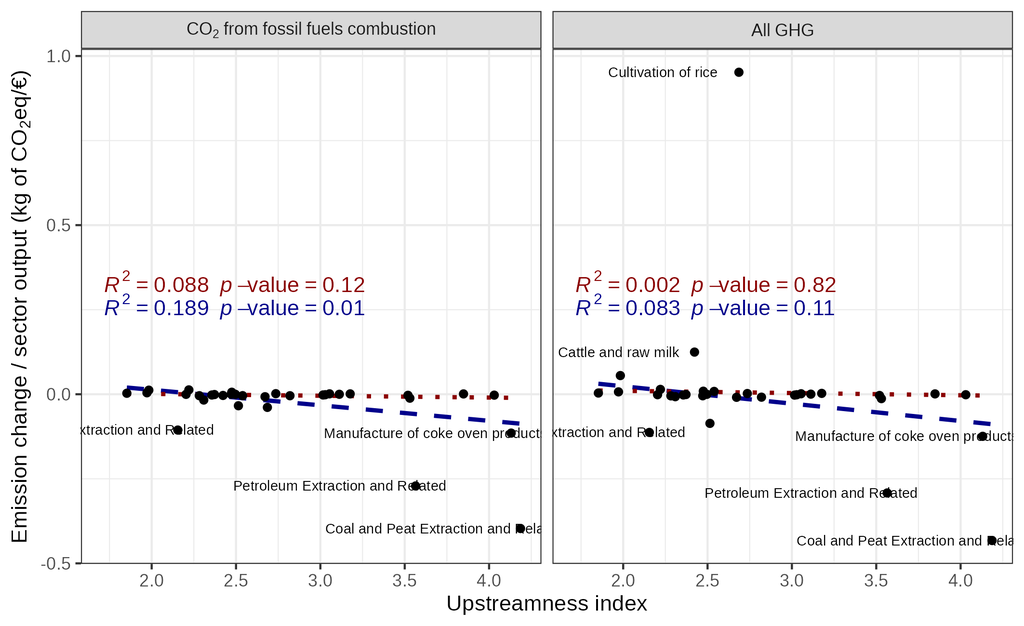

Blue: all sample / Red: Without fossil fuel sectors

# Extensions on fossil impact

## Extension 1: Finite natural resources

- In our model, fossil extraction only needs labor and intermediate goods
  - Natural resources and rents are ignored
  - Tariffs increase local production in an unrealistic way
- Extension to include natural resources in the production function
  - Value added is split between natural resource rents and other value added
  - Production function remains Cobb–Douglas
  - Rent = 0 for all sector except fossil extraction

## Extension 1: Results

| Sector | Standard model | Finite NR |
| --- | --- | --- |
| Agriculture (A) | 0.61 | 0.41 |
| Manufacturing n.e.s. (M) | 0.27 | 0.22 |
| Fossil Extraction (F) | -1.27 | -0.53 |
| Brown Industries (B) | -0.17 | -0.11 |
| Coal (C) | -0.39 | -0.19 |
| Oil (O) | -0.78 | -0.30 |
| Gas (G) | -0.09 | -0.04 |
| All | -0.58 | -0.04 |
| All except Fossil Extraction | 0.70 | 0.49 |

Results with CES functions

## Extension 2: Domestic taxes as tariffs

- Domestic taxes on fossil fuels
- Table
- For a non-producer:
  - Tax on fossil = uniform tariff (on all trade partners)
  - Taxes can have a trade reason: rent-extraction
- Special taxes on fossil (energy, CO$_2$) are often very high (20–50% on average for non-producers).
- Unique sector: concentrated production + special taxation
- What happens if we include these taxes as tariffs?

Ad valorem equivalent net tax (%) on fossil fuels for the regions with import shares above 99%

| Region | Coal | Oil | Gas |
| --- | --- | --- | --- |
| Belgium, Netherlands, and Luxembourg | 82.27 | 23.84 | - |
| Eastern EU countries in OECD data | - | 50.05 | - |
| France | 31.77 | 78.47 | 29.93 |
| Germany | - | 56.60 | - |
| Italy | 69.71 | - | - |
| Japan | 11.99 | 23.60 | 83.89 |
| Korea | 66.48 | 24.90 | 36.55 |
| Non EU European countries | - | 49.83 | 17.39 |
| Nordic countries in the EU | 59.23 | - | - |
| Norway | 7.37 | - | - |
| Other EU countries in OECD data | - | 56.53 | 65.41 |
| Spain | - | 55.83 | 49.14 |

Note: “-” indicates that for this fuel the region’s import share is below 99%.

Sources: Taxation calculated using OECD and EXIOBASE and net imports calculated from BP.

## Extension 2: Results

% change in GHG emissions

| Sector | Fossil tax not included (benchmark results) | With fossil tax for net imports > 99% |
| --- | --- | --- |
| All sectors | -0.58 | 2.14 |
| Agriculture | 0.61 | 0.65 |
| Fossils | -1.27 | 1.25 |
| Brown Industries | -0.17 | -0.12 |
| Manufacturing n.e.s. | 0.27 | 0.36 |

# Conclusion

- The carbon bias uncovered by Shapiro (2021) confirmed for 2007–19
- The bias is mostly due to the low of tariffs on fossils fuels
- Bias
  - abolished by accounting for natural resources in fossil fuel production
  - and reversed by accounting for domestic taxes in non-producing countries
- Bias very sensitive to simple modeling hypotheses
  - No robust ground for a large tariff reform

# Thank You !

Any question ?

# Appendix

## Model with nonlinearities

% change in GHG emissions

| Model | Parameterization (σ<sup>U</sup>, σ<sup>Q</sup>, σ<sup>IC</sup>, σ<sup>VA</sup>) | All | Fossils |
| --- | --- | --- | --- |
| Standard model | Benchmark (1, 1, 1) | -0.58 | -1.27 |
|  | as Baqaee-Fahri, except for σ<sup>VA</sup> (0.9, 0.5, 0.2) | -0.60 | -1.21 |
|  | low elasticities (0.9, 0.1, 0.2) | -0.61 | -1.17 |
|  | very low elasticities I (0.9, 0.05, 0.05) | -0.61 | -1.16 |
|  | very low elasticities II (0.1, 0.05, 0.05) | -0.59 | -1.09 |
| Finite natural resources | Benchmark (1, 1, 1, 1) | -0.04 | -0.53 |
|  | as Baqaee-Fahri (0.9, 0.5, 0.2, 1) | 0.00 | -0.46 |
|  | as Baqaee-Fahri, except for σ<sup>VA</sup> (0.9, 0.5, 0.2, 0.5) | 0.09 | -0.36 |
|  | low elasticities (0.9, 0.1, 0.2, 0.5) | 0.13 | -0.30 |
|  | very low elasticities I (0.9, 0.05, 0.05, 0.5) | 0.14 | -0.29 |
|  | very low elasticities II (0.1, 0.05, 0.05, 0.5) | 0.13 | -0.26 |

Back

## Notes

This work has benefited from the support of the Agence Nationale de la Recherche through the program Investissements d’Avenir ANR-17-EURE-0001.

The contribution of Youssef Salib to this work has been completed partly during an internship at the CEPII and partly during the PhD program at PSE.

## Bibliography

Caliendo, Lorenzo, and Fernando Parro. 2015. “Estimates of the Trade and Welfare Effects of NAFTA.” *The Review of Economic Studies* 82 (1): 1–44. https://doi.org/10.1093/restud/rdu035.

Chepeliev, M., and E. Corong. 2022. “Revisiting the Environmental Bias of Trade Policies Based on an Environmentally Extended GTAP MRIO Data Base.” Conference Paper. *Center for Global Trade Analysis, Purdue University*. GTAP.

Guerrero, Santiago, Ben Henderson, Hugo Valin, Charlotte Janssens, Petr Havlik, and Amanda Palazzo. 2022. “The Impacts of Agricultural Trade and Support Policy Reform on Climate Change Adaptation and Environmental Performance: A Model-Based Analysis.” OECD Food, Agriculture and Fisheries Papers 180. OECD Publishing. https://doi.org/10.1787/520dd70d-en.

Klotz, Richard, and Rishi R. Sharma. 2023. “Trade Barriers and CO$_2$.” *Journal of International Economics* 141 (March): 103726. https://doi.org/10.1016/j.jinteco.2023.103726.

Laborde, David, Abdullah Mamun, Will Martin, Valeria Piñeiro, and Rob Vos. 2020. “Modeling the Impacts of Agricultural Support Policies on Emissions from Agriculture.” IFPRI; National Bureau of Economic Research. https://doi.org/10.3386/w27202.

Moreira, Mauricio Mesquita, and Marcelo Dolabella. 2024. “Does Trade Policy Help or Hinder Global Warming? A Case Study of Latin America and the Caribbean.” *The World Economy* 47 (2): 779–805. https://doi.org/10.1111/twec.13449.

Shapiro, Joseph S. 2021. “The Environmental Bias of Trade Policy.” *The Quarterly Journal of Economics* 136 (2): 831–86. https://doi.org/10.1093/qje/qjaa042.